# Rural vs Urban Regression

*Confidence Interval for 2nd Year Retention Rate

```r
# bootstrap distribution
UCLA_BS2 <- UCLA_Regression %>%
  specify(response = `2nd Year Retention Rate`) %>%
  generate(reps = 1000, type = "bootstrap") %>%
  calculate(stat = "mean")
UCLA_BS2 %>%
  get_confidence_interval(level = 0.95, type = "percentile")
```

```
## # A tibble: 1 × 2
##   lower_ci upper_ci
##      <dbl>    <dbl>
## 1    0.964    0.968
```

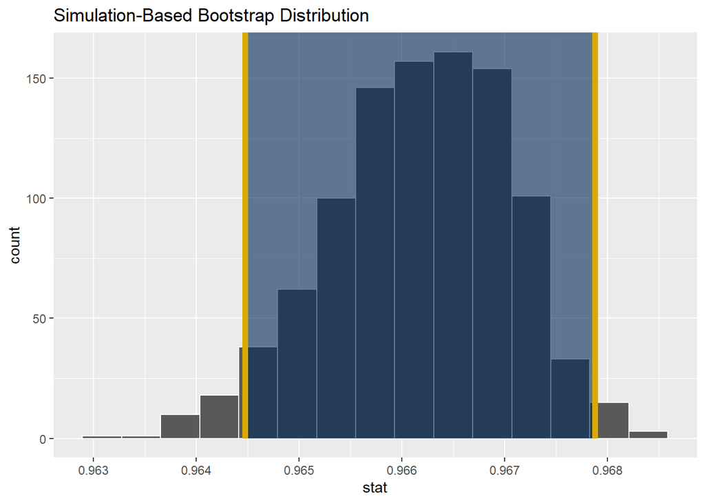

```r
UCLA_BS2_1 <- UCLA_BS2 %>%
  get_ci(point_estimate = mean(UCLA_BS2$stat),
         level = 0.95, type = "se")

visualize(UCLA_BS2) +
  shade_ci(endpoints = UCLA_BS2_1, color = "#DAA900", fill = "#002856")
```

*Confidence Interval for 3rd Year Retention Rate

```r
# bootstrap distribution
UCLA_BS3 <- UCLA_Regression %>%
  specify(response = `3rd Year Retention Rate`) %>%
  generate(reps = 1000, type = "bootstrap") %>%
  calculate(stat = "mean")
#Great Confidence Levels 90<x
```

```r
UCLA_BS3 %>%
  get_confidence_interval(level = 0.95, type = "percentile")
```

```
## # A tibble: 1 × 2
##   lower_ci upper_ci
##      <dbl>    <dbl>
## 1    0.925    0.934
```

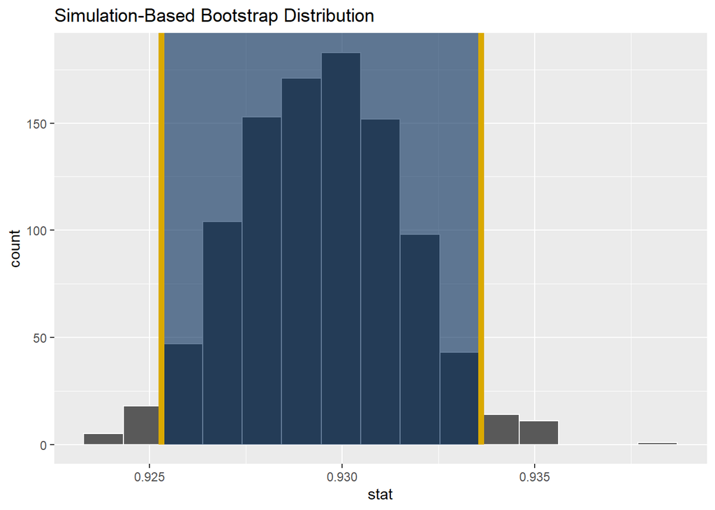

```r
UCLA_BS3_2 <- UCLA_BS3 %>%
  get_ci(point_estimate = mean(UCLA_BS3$stat),
         level = 0.95, type = "se")

visualize(UCLA_BS3) +
  shade_ci(endpoints = UCLA_BS3_2, color = "#DAA900", fill = "#002856")
```

*Confidence Interval for 4th Year Retention Rate

```r
# bootstrap distribution
UCLA_BS4 <- UCLA_Regression %>%
  specify(response = `4th Year Retention Rate`) %>%
  generate(reps = 1000, type = "bootstrap") %>%
  calculate(stat = "mean")
#Great Confidence Levels 90<x
```

```r
UCLA_BS4 %>%
  get_confidence_interval(level = 0.95, type = "percentile")
```

```
## # A tibble: 1 × 2
##   lower_ci upper_ci
##      <dbl>    <dbl>
## 1    0.882    0.892
```

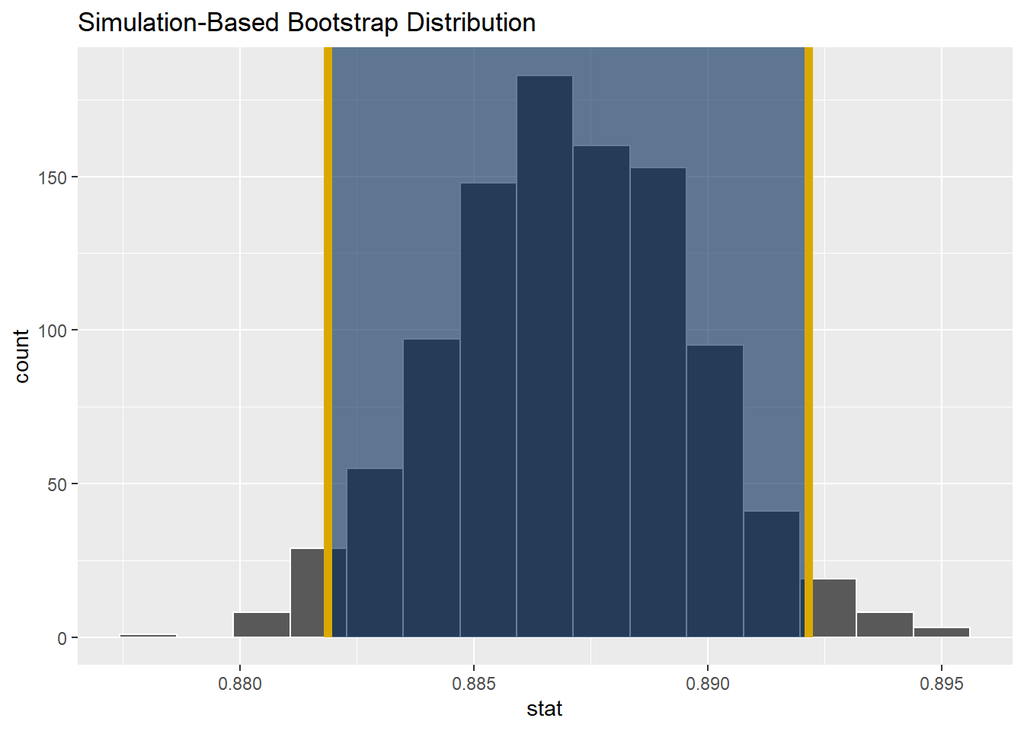

```r
UCLA_BS4_2 <- UCLA_BS4 %>%
  get_ci(point_estimate = mean(UCLA_BS4$stat),
         level = 0.95, type = "se")

visualize(UCLA_BS4) +
  shade_ci(endpoints = UCLA_BS4_2, color = "#DAA900", fill = "#002856")
```

```r
#Alright Confindence Interval 85<x
```

*Confidence Interval for 5th Year Retention Rate

```r
# bootstrap distribution
UCLA_BS5<- UCLA_Regression %>%
  specify(response = `5th Year Retention Rate`) %>%
  generate(reps = 1000, type = "bootstrap") %>%
  calculate(stat = "mean")
UCLA_BS5 %>%
  get_confidence_interval(level = 0.95, type = "percentile")
```

```
## # A tibble: 1 × 2
##   lower_ci upper_ci
##      <dbl>    <dbl>
## 1    0.112    0.162
```

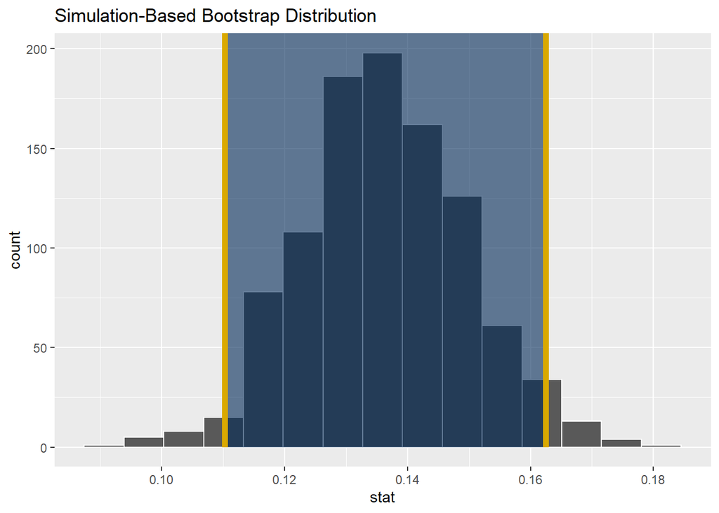

```r
UCLA_BS5_2 <- UCLA_BS5 %>%
  get_ci(point_estimate = mean(UCLA_BS5$stat),
         level = 0.95, type = "se")

visualize(UCLA_BS5) +
  shade_ci(endpoints = UCLA_BS5_2, color = "#DAA900", fill = "#002856")
```

```r
#Terrible Confidence Levels 50>x
```

*Confidence Interval for 6th Year Retention Rate

```r
# bootstrap distribution
UCLA_BS6 <- UCLA_Regression %>%
  specify(response = `6th Year Retention Rate`) %>%
  generate(reps = 1000, type = "bootstrap") %>%
  calculate(stat = "mean")
UCLA_BS6 %>%
  get_confidence_interval(level = 0.95, type = "percentile")
```

```
## # A tibble: 1 × 2
##   lower_ci upper_ci
##      <dbl>    <dbl>
## 1   0.0154   0.0196
```

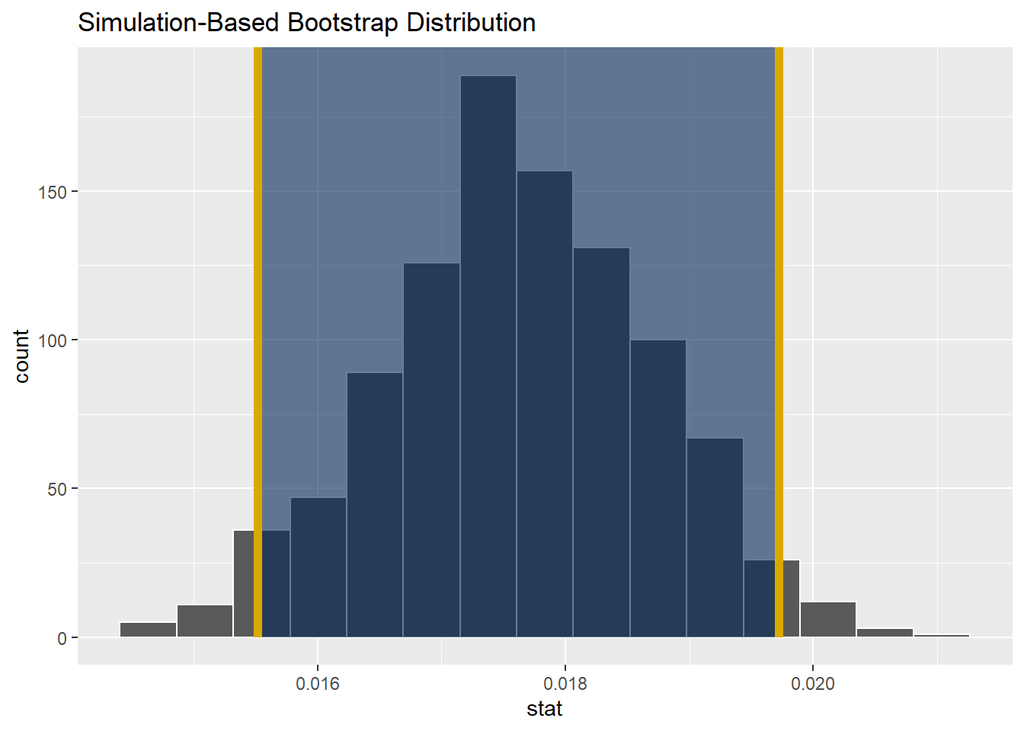

```r
UCLA_BS6_2 <- UCLA_BS6 %>%
  get_ci(point_estimate = mean(UCLA_BS6$stat),
         level = 0.95, type = "se")

visualize(UCLA_BS6) +
  shade_ci(endpoints = UCLA_BS6_2, color = "#DAA900", fill = "#002856")
```

```r
#Terrible Confidence Levels 50>x
```

*Confidence Interval for 2nd Year Graduation Rate

```r
# bootstrap distribution
UCLA_BS2g <- UCLA_Regression %>%
  specify(response = `2nd Year Graduation Rate`) %>%
  generate(reps = 1000, type = "bootstrap") %>%
  calculate(stat = "mean")
UCLA_BS2g %>%
  get_confidence_interval(level = 0.95, type = "percentile")
```

```
## # A tibble: 1 × 2
##   lower_ci upper_ci
##      <dbl>    <dbl>
## 1 0.000806  0.00143
```

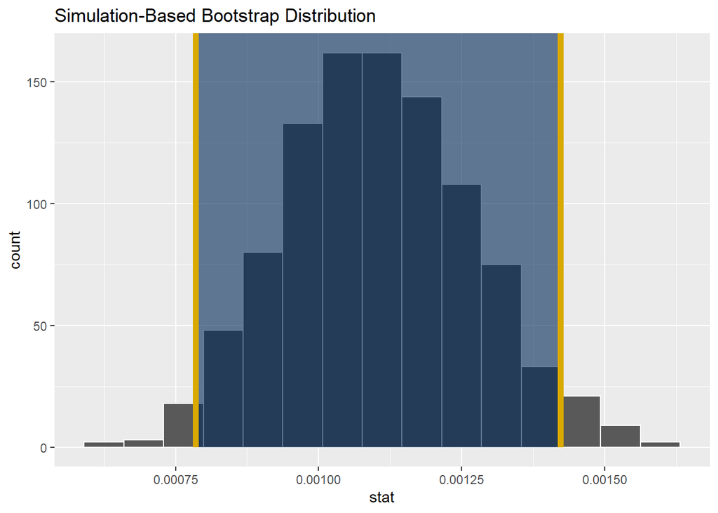

```r
UCLA_BS2_1.g <- UCLA_BS2g %>%
  get_ci(point_estimate = mean(UCLA_BS2g$stat),
         level = 0.95, type = "se")

visualize(UCLA_BS2g) +
  shade_ci(endpoints = UCLA_BS2_1.g, color = "#DAA900", fill = "#002856")
```

```r
#Terrible Confidence Levels 50>x
```

```r
# bootstrap distribution
UCLA_BS3g <- UCLA_Regression %>%
  specify(response = `3rd Year Retention Rate`) %>%
  generate(reps = 1000, type = "bootstrap") %>%
  calculate(stat = "mean")
UCLA_BS3g %>%
  get_confidence_interval(level = 0.95, type = "percentile")
```

```
## # A tibble: 1 × 2
##   lower_ci upper_ci
##      <dbl>    <dbl>
## 1    0.926    0.933
```

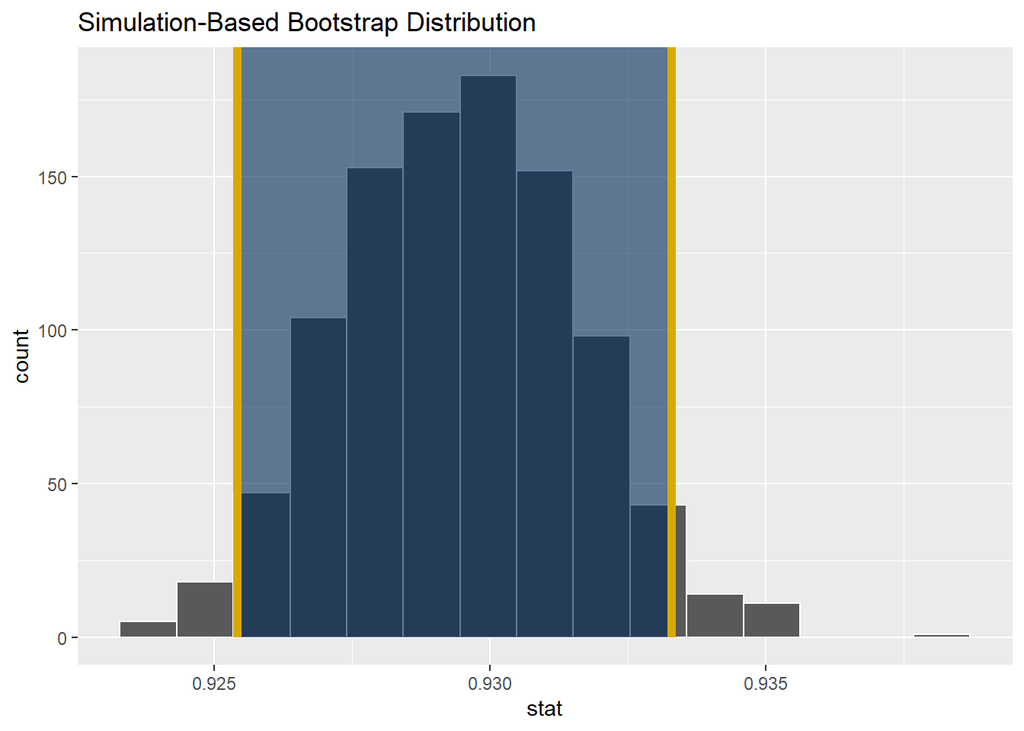

```r
UCLA_BS3_2.g <- UCLA_BS3g %>%
  get_ci(point_estimate = mean(UCLA_BS3g$stat),
         level = 0.95, type = "se")

visualize(UCLA_BS3) +
  shade_ci(endpoints = UCLA_BS3_2.g, color = "#DAA900", fill = "#002856")
```

```r
#Great Confidence Levels 90<x
```

*Confidence Interval for 4th Year Graduation Rate

```r
# bootstrap distribution
UCLA_BS4g <- UCLA_Regression %>%
  specify(response = `4th Year Graduation Rate`) %>%
  generate(reps = 1000, type = "bootstrap") %>%
  calculate(stat = "mean")
UCLA_BS4g %>%
  get_confidence_interval(level = 0.95, type = "percentile")
```

```
## # A tibble: 1 × 2
##   lower_ci upper_ci
##      <dbl>    <dbl>
## 1    0.740    0.800
```

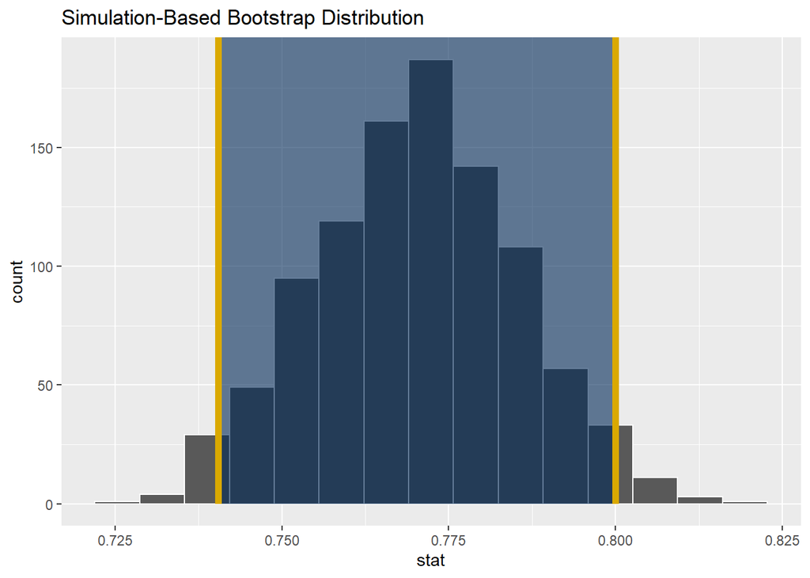

```r
UCLA_BS4_2.g <- UCLA_BS4g %>%
  get_ci(point_estimate = mean(UCLA_BS4g$stat),
         level = 0.95, type = "se")

visualize(UCLA_BS4g) +
  shade_ci(endpoints = UCLA_BS4_2.g, color = "#DAA900", fill = "#002856")
```

```r
#Worrisome Confidence Levels 89>x
```

*Confidence Interval for 5th Year Graduation Rate

```r
# bootstrap distribution
UCLA_BS5g<- UCLA_Regression %>%
  specify(response = `5th Year Graduation Rate`) %>%
  generate(reps = 1000, type = "bootstrap") %>%
  calculate(stat = "mean")
UCLA_BS5g %>%
  get_confidence_interval(level = 0.95, type = "percentile")
```

```
## # A tibble: 1 × 2
##   lower_ci upper_ci
##      <dbl>    <dbl>
## 1    0.893    0.903
```

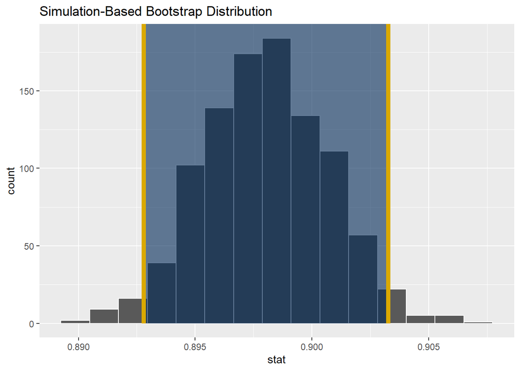

```r
UCLA_BS5_2.g <- UCLA_BS5g %>%
  get_ci(point_estimate = mean(UCLA_BS5g$stat),
         level = 0.95, type = "se")

visualize(UCLA_BS5g) +
  shade_ci(endpoints = UCLA_BS5_2.g, color = "#DAA900", fill = "#002856")
```

```r
#Alright, but not great Confidence Levels 89<x<90
```

*Confidence Interval for 6th Year Graduation Rate

```r
# bootstrap distribution
UCLA_BS6g <- UCLA_Regression %>%
  specify(response = `6th Year Graduation Rate`) %>%
  generate(reps = 1000, type = "bootstrap") %>%
  calculate(stat = "mean")
UCLA_BS6g %>%
  get_confidence_interval(level = 0.95, type = "percentile")
```

```
## # A tibble: 1 × 2
##   lower_ci upper_ci
##      <dbl>    <dbl>
## 1    0.910    0.917
```

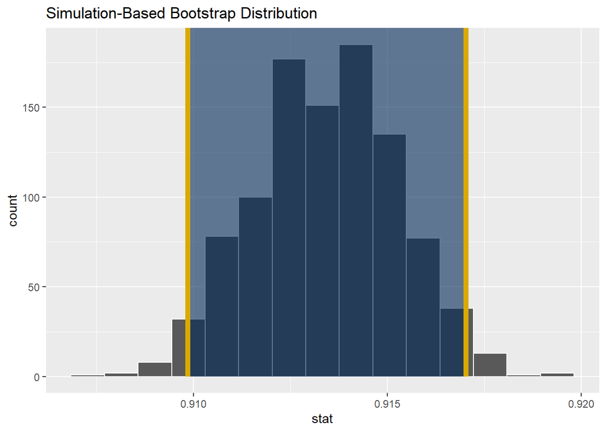

```r
UCLA_BS6_2.g<- UCLA_BS6g %>%
  get_ci(point_estimate = mean(UCLA_BS6g$stat),
         level = 0.95, type = "se")

visualize(UCLA_BS6g) +
  shade_ci(endpoints = UCLA_BS6_2.g, color = "#DAA900", fill = "#002856")
```

```r
#Good Confidence Levels x>90
```

##Probability Distribution UCM

*4 Year plan for Entry Fall 2005

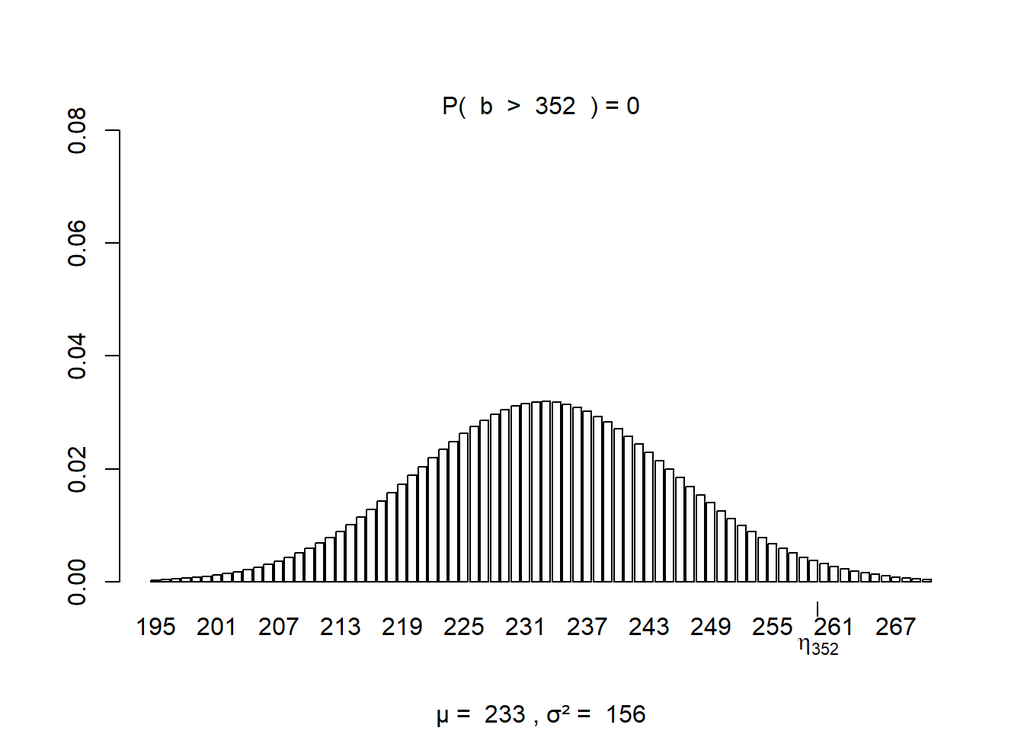

```
## numeric(0)
```

```r
#If sampled, chances are Half of size will had not graduated within 4 years
1-visualize.binom(stat = 352, size = 706, prob = 0.33, section = "upper", strict = TRUE)
```

*4 Year plan for Entry Fall 2006

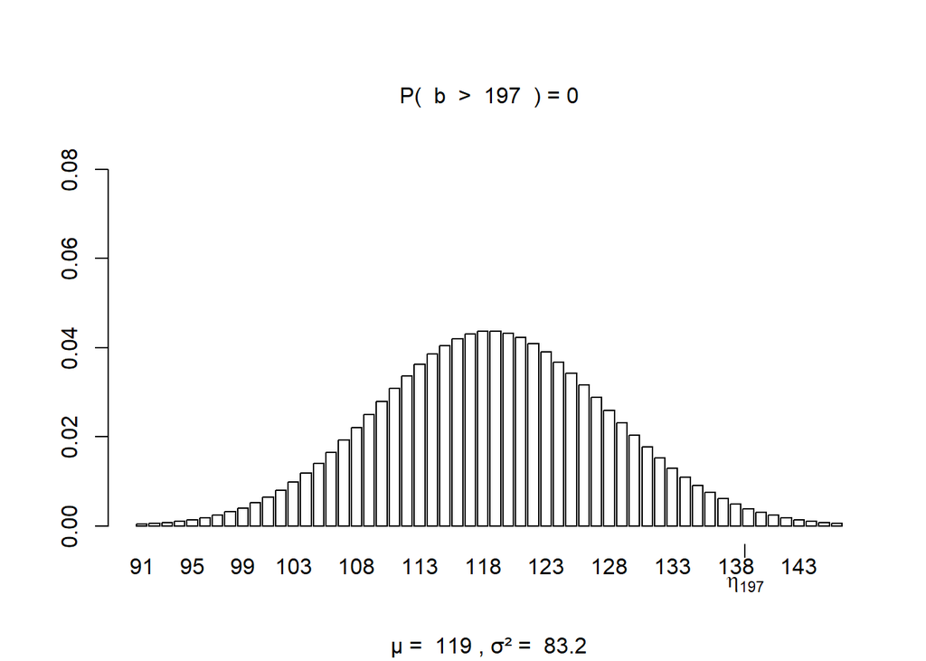

```
## numeric(0)
```

```r
#If sampled, chances are Half of size will had not graduated within 4 years
1-visualize.binom(stat = 197, size = 396, prob = 0.30, section = "upper", strict = TRUE)
```

*4 Year plan for Entry Fall 2007

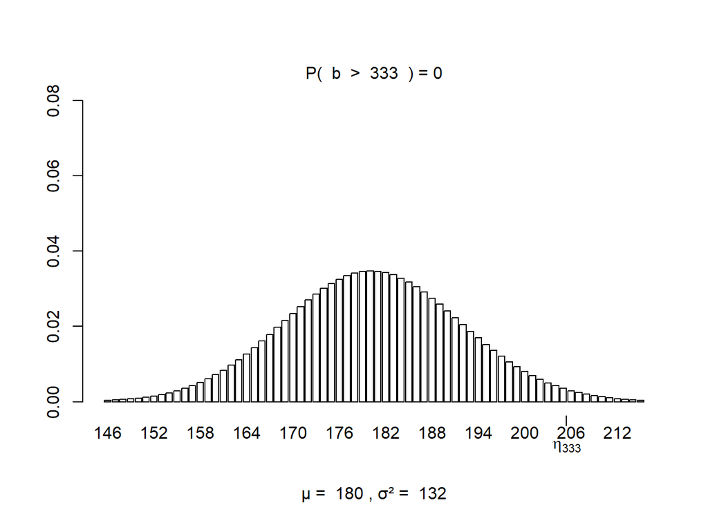

```
## numeric(0)
```

```r
#If sampled, chances are Half of size will had not graduated within 4 years
1-visualize.binom(stat = 333, size = 668, prob = 0.27, section = "upper", strict = TRUE)
```

*4 Year plan for Entry Fall 2008

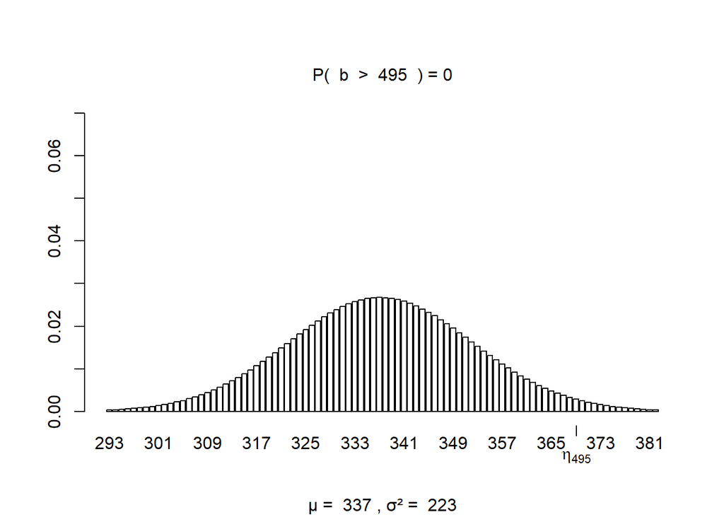

```
## numeric(0)
```

```r
#If sampled, chances are Half of size will had not graduated within 4 years
1-visualize.binom(stat = 495, size = 992, prob = 0.34, section = "upper", strict = TRUE)
```

*4 Year plan for Entry Fall 2009

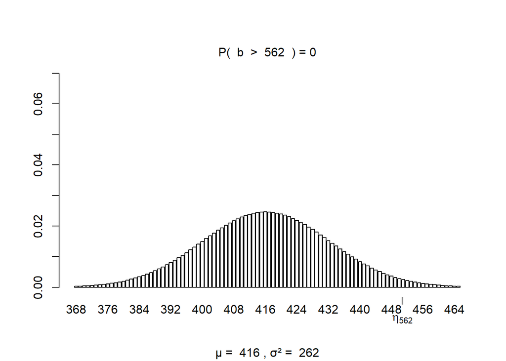

```
## numeric(0)
```

```r
#If sampled, chances are Half of size will had not graduated within 4 years
1-visualize.binom(stat = 562, size = 1125, prob = 0.37, section = "upper", strict = TRUE)
```

*4 Year plan for Entry Fall 2010

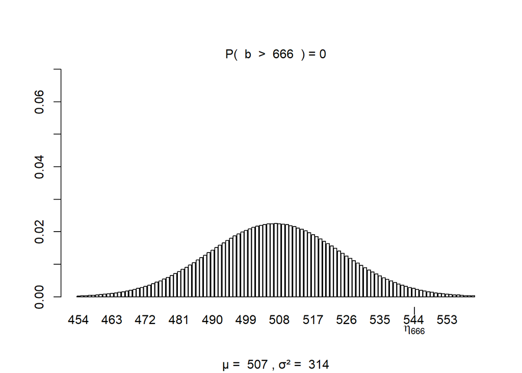

```
## numeric(0)
```

```r
#If sampled, chances are Half of size will had not graduated within 4 years
1-visualize.binom(stat = 666, size = 1334, prob = 0.38, section = "upper", strict = TRUE)
```

*4 Year plan for Entry Fall 2011

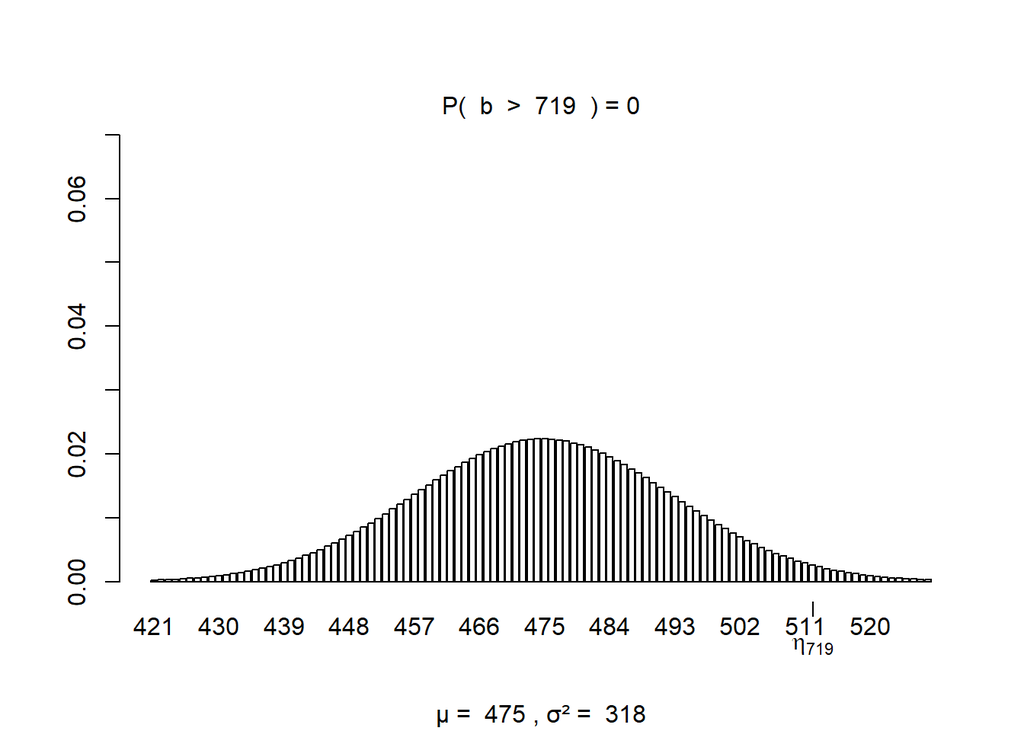

```
## numeric(0)
```

```r
#If sampled, chances are Half of size will had not graduated within 4 years
1-visualize.binom(stat = 719, size = 1439, prob = 0.33, section = "upper", strict = TRUE)
```

*4 Year plan for Entry Fall 2012

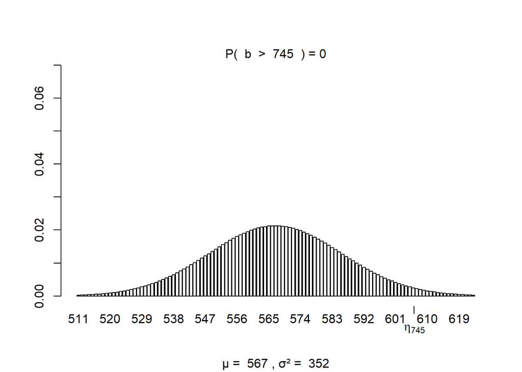

```
## numeric(0)
```

```r
#If sampled, chances are Half of size will had not graduated within 4 years
1-visualize.binom(stat = 745, size = 1492, prob = 0.38, section = "upper", strict = TRUE)
```

*4 Year plan for Entry Fall 2013

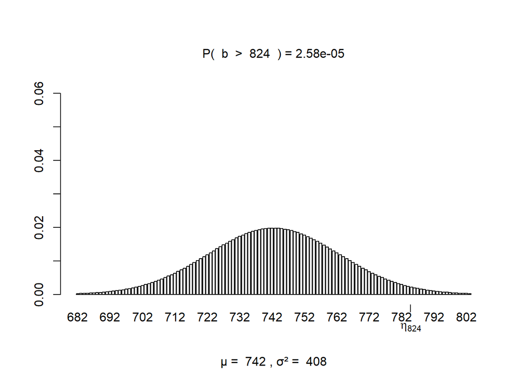

```
## numeric(0)
```

```r
#If sampled, chances are Half of size will had not graduated within 4 years
1-visualize.binom(stat = 824, size = 1650, prob = 0.45, section = "upper", strict = TRUE)
```